# 03_author_similarity

This notebook gives a preview of some of the research I have done for my third dissertation chapter, in which I am working with a dataset derived from the digitized contents of the Book Review Index from 1965-2000. For this demonstration, I'm just working with the 1965-1984 cumulation of the data. This dataset tracks which of ~350 publications reviewed almost 1 million books in that period.

In what follows, I model the data from 1965-1984 as a journal - author matrix: columns are journals, rows are authors, and each cell represents the number of times that author was reviewed by that journal. This allows us to make similarity comparisons between authors that have a remarkable degree of intuitive consistency: authors are naturally grouped by genre, status, profession, and even nationality.

```python
import math
import time

import pandas as pd
import numpy as np
import seaborn as sns
from matplotlib import pyplot as plt

# for t-SNE visualization
from sklearn.decomposition import TruncatedSVD
from sklearn.manifold import TSNE

# for plotting, we will use Bokeh for the excellent interactive options
from bokeh.plotting import figure, show, output_file
from bokeh.models import ColumnDataSource, HoverTool, CategoricalColorMapper, Legend
```

The processed data tracks reviews at the level of titles. This cell instead groups by authors.

```python
df = pd.read_csv('../../data/processed/book_reviews.tsv', sep='\t', index_col=0)
df['author_name'] = df.index.to_series().str.split('\\|\\|').str[1].str.strip()
author_total_books = df['author_name'].value_counts()
df = df.groupby('author_name').sum()
df = df[df.index.notnull()]
df = df.drop('#NAME?')
df.head()
```

| author_name | AB Bookman's Weekly | Publishers Weekly | Esquire | Booklist | Journal of Aesthetics and Art Criticism | International Philosophical Quarterly | Journal of Marketing | Harvard Law Review | Journal of Business Education | Journal of Home Economics | ... | Black Warrior Review | Computers and the Humanities | American Arts | Essays on Canadian Writing` | Performing Arts Review | Journal of Arts Management, Law, and Society | Studio International, Review | Journal of Black Studies | Lone Star Review | Aspen Journal of the Arts |
| --- | --- | --- | --- | --- | --- | --- | --- | --- | --- | --- | --- | --- | --- | --- | --- | --- | --- | --- | --- | --- | --- |
|  | 0 | 0 | 0 | 1 | 0 | 0 | 0 | 0 | 0 | 0 | ... | 0 | 0 | 0 | 0 | 0 | 0 | 0 | 0 | 0 | 0 |
| AABERG, Jean | 2 | 1 | 0 | 0 | 0 | 0 | 0 | 0 | 0 | 0 | ... | 0 | 0 | 0 | 0 | 0 | 0 | 0 | 0 | 0 | 0 |
| AADLAND, Florence | 0 | 0 | 1 | 0 | 0 | 0 | 0 | 0 | 0 | 0 | ... | 0 | 0 | 0 | 0 | 0 | 0 | 0 | 0 | 0 | 0 |
| AAFJES, Bertus | 0 | 0 | 0 | 1 | 0 | 0 | 0 | 0 | 0 | 0 | ... | 0 | 0 | 0 | 0 | 0 | 0 | 0 | 0 | 0 | 0 |
| AAGAARD, Orlena | 0 | 0 | 0 | 1 | 0 | 0 | 0 | 0 | 0 | 0 | ... | 0 | 0 | 0 | 0 | 0 | 0 | 0 | 0 | 0 | 0 |

5 rows × 485 columns

Let's see how much data we're working with. By summing over the entire dataframe, we can also see the total number of reviews.

```python
print(df.shape)
print(df.sum().sum())
```

```
(167445, 485)
968080
```

This method of representing the data is similar to how you might represent customer-item interactions in a simple recommender system. As in that application, we're going to restrict the data to only authors who have received a minimum number of reviews. I've selected 20, because this yields a manageable number for visualization.

```python
auth_min = 20
journal_min = 25
df = df[df.sum(axis=1) >= auth_min]
df = df[df.columns[df.sum() >= journal_min]]
author_total_books = author_total_books[df.index]
print(df.shape)
print(df.sum().sum())
```

```
(9043, 352)
430173
```

Our goal is to find authors who are reviewed in similar venues. The problem is that our venues have extremely lopsided levels of coverage. Compare the total number of reviews in Publishers Weekly to the total in Analog Science Fiction and Fact:

```python
pw_total = df['Publishers Weekly'].sum()
an_total = df['Analog Science Fiction and Fact'].sum()
print(f'Publishers Weekly total: {pw_total}')
print(f'Analog total: {an_total}')
```

```
Publishers Weekly total: 29769
Analog total: 456
```

The full set of publications has a long tail: a few journals just publish an order of magnitude more reviews than the "typical" journal. The x-axis is on a log-scale because the plot is pretty incoherent otherwise.

It looks like most journals have a few hundred reviews, whereas a smaller number published a few thousand or even more than 10,000.

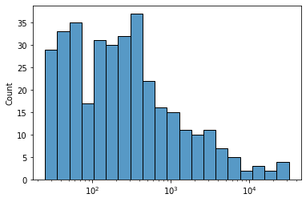

```python
journal_totals = df.sum(axis=0)
review_count_hist = sns.histplot(
    journal_totals,
    log_scale=(True, False),
    bins=20
)
plt.show()
```

This disproportion might throw off comparisons. If Publishers Weekly, Booklist, and Choice review just about everybody, then it isn't very informative to know that an author was reviewed by one of those journals. What we want is a number that tells us how much more an author was reviewed by a journal than other authors were.

I've played around with three different methods for normalizing the data in this way: standard scaling (Z-scores), TF-IDF scores, and pointwise mutual information. For this demonstration, I'm just going to use standard scaling.

```python
weighting_scheme = 'standard'

if weighting_scheme == 'standard':
    from sklearn.preprocessing import StandardScaler
    scaler = StandardScaler()
    weighted = scaler.fit_transform(df)
    weighted = pd.DataFrame(weighted, index=df.index, columns=df.columns)
elif weighting_scheme == 'TFIDF':
    docs = df.shape[0]
    idfs = [math.log(docs / np.where(df[col] == 0, 0, 1).sum()) for col in df.columns]
    weighted = df * idfs
elif weighting_scheme == 'PMI':

    p_joint = df / df.sum().sum() # P(author, journal)
    p_j = df.sum() / df.sum().sum() # P(journal)
    p_a = author_total_books / author_total_books.sum() # P(author)
    p_independent = p_a.apply(lambda a: a * p_j) # P(author) * P(journal)
    weighted = (p_joint / p_independent) + 1 # PMI, then add 1 to allow us to take the log
    weighted = pd.DataFrame(np.ma.log(weighted.values).filled(0), # take the log, then subtract back that 1
                            index=weighted.index,
                            columns=weighted.columns) - 1


weighted.head()
```

| author_name | AB Bookman's Weekly | Publishers Weekly | Esquire | Booklist | Journal of Aesthetics and Art Criticism | International Philosophical Quarterly | Harvard Law Review | Journal of Home Economics | Social Education | Library Journal | ... | Journal of Negro Education | Foreign Affairs | Thought | Political Science Reviewer | Mankind | Black Scholar | Social Research | Religious Studies | Daedalus | Threepenny Review |
| --- | --- | --- | --- | --- | --- | --- | --- | --- | --- | --- | --- | --- | --- | --- | --- | --- | --- | --- | --- | --- | --- |
| AARDEMA, Verna | -0.281898 | 0.873116 | -0.184596 | 1.423560 | -0.114113 | -0.048713 | -0.080852 | -0.056622 | 5.010613 | -0.652932 | ... | -0.064776 | -0.057693 | -0.038791 | -0.047681 | -0.077693 | -0.049667 | -0.052652 | -0.0555 | -0.024265 | -0.026197 |
| AARON, Chester | -0.281898 | 0.166723 | -0.184596 | 0.566514 | -0.114113 | -0.048713 | -0.080852 | -0.056622 | 2.396317 | -0.130159 | ... | -0.064776 | -0.057693 | -0.038791 | -0.047681 | -0.077693 | -0.049667 | -0.052652 | -0.0555 | -0.024265 | -0.026197 |
| AARON, Daniel | -0.281898 | -0.304205 | -0.184596 | -0.504793 | -0.114113 | -0.048713 | -0.080852 | -0.056622 | -0.217978 | -0.652932 | ... | -0.064776 | -0.057693 | -0.038791 | -0.047681 | -0.077693 | -0.049667 | -0.052652 | -0.0555 | -0.024265 | -0.026197 |
| AARON, Henry J | -0.281898 | -0.775134 | -0.184596 | -0.290531 | -0.114113 | -0.048713 | -0.080852 | -0.056622 | -0.217978 | 0.131228 | ... | -0.064776 | -0.057693 | -0.038791 | -0.047681 | -0.077693 | -0.049667 | -0.052652 | -0.0555 | -0.024265 | -0.026197 |
| AASENG, Nathan | -0.281898 | -0.775134 | -0.184596 | 7.851402 | -0.114113 | -0.048713 | -0.080852 | -0.056622 | -0.217978 | -0.914318 | ... | -0.064776 | -0.057693 | -0.038791 | -0.047681 | -0.077693 | -0.049667 | -0.052652 | -0.0555 | -0.024265 | -0.026197 |

5 rows × 352 columns

Now, we can search for a specific author and see two things:

1) their highest journal scores, that is, journals in which they are unusually prominent 2) their most similar authors, that is, authors that were reviewed in a similar collection of journals

For similarity, I'll use Pearson's R. You could also use a distance metric, like Euclidean distance or cosine distance. According to at [least one paper](https://www.huichawaii.org/assets/met_morozov_sergey_2013.pdf), Pearson's outperforms Euclidean and cosine for recommendations.

```python
from scipy.stats import pearsonr

def author_query(
    df,
    author: str,
    num_journals: int = 5,
    num_authors: int = 5
    ):

    print(author)
    print('Top Journal Scores:')
    print(df.loc[author].sort_values(ascending=False)[:num_journals])
    print()

    author_vector = df.loc[author]
    similarities = df.drop(author).apply(lambda x: pearsonr(x, author_vector), axis=1)

    print('Most Similar Authors:')
    print(similarities.sort_values()[::-1][:num_authors])
    print()
```

Here is a somewhat arbitrary list of authors against which to make comparisons. I find the results really fascinating; you can get a taste of cleavages within the data along axes of genre, race, status, and politics. Remember that this is based on nothing other than the fact that these authors tended to be reviewed in similar journals. This information turns out to tell you a lot about the context of their reception.

```python
query_authors = [

    'LE GUIN, Ursula K',
    'MORRISON, Toni',
    'MERTON, Thomas', # Christian monk
    'KENNEDY, Eugene', # Catholic priest
    'UPDIKE, John',
    'ZINN, Howard',
    'BENNETT, Lerone, Jr.', # social historian of race
    'CAUSLEY, Charles', # British children's poet, known for blurring lines between lit for kids/adults
    'SENDAK, Maurice',
    'RICE, Anne',
    'TYLER, Anne',
    'PYNCHON, Thomas'

]

for author in query_authors:
    author_query(weighted, author)
```

```
LE GUIN, Ursula K
Top Journal Scores:
Emergency Librarian                        16.177252
New Age Journal                            13.913492
English Journal                            10.664482
Book Report                                10.049862
Magazine of Fantasy and Science Fiction    10.047733
Name: LE GUIN, Ursula K, dtype: float64

Most Similar Authors:
author_name
MC KINLEY, Robin          (0.5528115927876553, 1.4651648937133513e-29)
WALSH, Jill Paton           (0.5264999590498307, 1.70993924355456e-26)
OXENBURY, Helen            (0.5201867871874256, 8.506955391601144e-26)
MC KILLIP, Patricia A      (0.5161226140849589, 2.347997852360038e-25)
ANGELL, Judie            (0.49897481847179126, 1.4699499707507178e-23)
dtype: object

MORRISON, Toni
Top Journal Scores:
Black Scholar    59.835853
Critique         17.461670
Black World      16.720440
Ms.              13.332273
Cresset           6.865729
Name: MORRISON, Toni, dtype: float64

Most Similar Authors:
author_name
DUMAS, Henry               (0.877432209012966, 1.060775142523341e-113)
BAMBARA, Toni Cade          (0.7774150997378938, 1.83205166005727e-72)
ARMAH, Ayi Kwei             (0.775399191524083, 7.295234900612199e-72)
KELLEY, William Melvin     (0.6948979408922896, 4.617259254309341e-52)
RUSSELL, Ross             (0.6921805372380505, 1.6520768255798344e-51)
dtype: object

MERTON, Thomas
Top Journal Scores:
Critic                      18.657915
Christian Century           16.284860
```

[output cut: 160 more lines]

```
Harper's Magazine        7.160074
Saturday Review/World    4.720596
Critique                 4.317086
Prairie Schooner         3.786981
Partisan Review          3.502168
Name: PYNCHON, Thomas, dtype: float64

Most Similar Authors:
author_name
KAUFMAN, Sue         (0.5924577991661754, 9.92606145784547e-35)
BARTH, John        (0.5598444128606803, 1.9914938304178426e-30)
PALEY, Grace         (0.5582812412190425, 3.11604880120294e-30)
MOSTERT, Noel      (0.5195069649305338, 1.0091175318715678e-25)
KOSINSKI, Jerzy     (0.517056759606564, 1.8615545714276522e-25)
dtype: object
```

The natural next step is to want to see a visualization of the entire space in which authors that have high scores in the same journals are grouped together.

Before doing that, I'm going to create a simple dictionary that associates each author with their top 5 journals. This will be included as a tooltip for that author visible when mousing over their point in the visualization. This is useful just because I have no idea who most of these people are; having their top journals makes them easier to Google, if I encounter them while browsing the visualization.

```python
author_dict = {}
for author in weighted.index:
    top_10 = weighted.loc[author].sort_values(ascending=False)[:5]
    author_dict[author] = top_10.index
```

There are different ways of producing such a visualization: t-SNE, UMAP, PCA, etc. I'm going to use t-SNE because I've used it before. t-SNE tries to find a lower-dimensional projection of the data that retains the local (but not necessarily global) structure of the data.

```python
time_start = time.time()
tsne = TSNE(n_components=2,
            verbose=0,
            perplexity=40,
            n_iter=300,
            learning_rate='auto',
            random_state=11,
            init='pca')
tsne_svd_results = tsne.fit_transform(weighted)
print('t-SNE done! Time elapsed: {} seconds'.format(time.time()-time_start))
```

```
t-SNE done! Time elapsed: 8.81271767616272 seconds
```

Finally, we'll make a scatterplot with a mouseover that gives us the name of the author and their top-scoring journals. Authors will tend to be grouped near other authors reviewed by the same venues.

```python
source = ColumnDataSource(data=dict(
    x=tsne_svd_results[:,0],
    y=tsne_svd_results[:,1],
    author=weighted.index,
    top_scores = [author_dict[author] for author in weighted.index],

))
TOOLTIPS = [
    ("(x,y)", "($x, $y)"),
    ("author", "@author"),
    ("top scores", "@top_scores"),
]

p = figure(plot_width=1000, plot_height=800, tooltips=TOOLTIPS, toolbar_location='above',
           title="t-SNE Projection of ~9000 Authors in Book Review Space")
p.scatter('x',
          'y',
          size=7,
          source=source,
          fill_alpha=1,
)

output_file(
    f"../../images/tsne_interactive_{weighting_scheme}.html",
    title=f"t-SNE Projection of {len(weighted.index)} Authors in Book Review Space"
)
```

Take some time to look it over. You will note that the clusters have a high degree of intuitive structure. Just browsing, I found a cluster of 19th century American authors (Twain, Fennimore Cooper, Melville, etc), a Canadian cluster, a science fiction cluster, and more.

```python
from IPython.display import IFrame

IFrame(src=f'../../images/tsne_interactive_{weighting_scheme}.html', width=1000, height=800)
```

[interactive chart not shown]